# More on Vectors, Linear Combinations, and Spanning Sets.

Brody Erlandson

# More on Vectors

## Definitions and Theorems

### Definition 1.1

**Vector Equality**

Two vectors $\mathbf{u}, \mathbf{v} \in \mathbb{C}^n$ are equal, if $\mathbf{u}_i = \mathbf{v}_i \ \forall \ i \in \{k \in \mathbb{N}|k<n\}$

### Definition 1.2

**Vector Addition**

Given $\mathbf{u}, \mathbf{v} \in \mathbb{C}^n$,

$$\mathbf{u} + \mathbf{v} = \begin{bmatrix}
u_1 + v_1\\
u_2 + v_2\\
\vdots \\
u_n + v_n
\end{bmatrix}$$

### Definition 1.3

**Scalar Multiplication**

Given $\mathbf{v} \in \mathbb{C}^n$ and $c \in \mathbb{C}$,

$$c\mathbf{v} = \begin{bmatrix}
cv_1\\
cv_2\\
\vdots \\
cv_n
\end{bmatrix}$$

With definitions 1.1, 1.2, and 1.3, we can prove the following

### Theorem 1.1.

**Properties of Column Vectors**

If $\mathbf{u}, \mathbf{v}, \mathbf{w} \in \mathbb{C}^n$, and $a, b \in \mathbb{C}$, then:

1. $\mathbf{u} + \mathbf{v} = \mathbf{v} + \mathbf{u}$ (commutative)
2. $\mathbf{u} + (\mathbf{v} + \mathbf{w}) = (\mathbf{u} + \mathbf{v}) + \mathbf{w}$ (associative)
3. $\mathbf{u} + \mathbf{0} = \mathbf{u}$
4. $\mathbf{u} + (−\mathbf{u}) = \mathbf{0}, \text{where} −\mathbf{u} = (−1)\mathbf{u}$
5. $a(\mathbf{u} + \mathbf{v}) = a\mathbf{u} + a\mathbf{v}$
6. $(a + b)\mathbf{u} = a\mathbf{u} + b\mathbf{u}$ (distributive)
7. $a(b\mathbf{u}) = (ab)\mathbf{u}$
8. $1\mathbf{u} = \mathbf{u}$

*Proof* of 1: Assume we have $\mathbf{u}, \mathbf{v} \in \mathbb{C}^n$. By definition, each component of the vector $\mathbf{u} + \mathbf{v}$ is $u_i + v_i \ \forall \ i \in [1, n]^\mathbb{Z}$. We know that scalars are commutative with addition, so $u_i + v_i = v_i + u_i \Rightarrow \mathbf{u} + \mathbf{v} = \mathbf{v} + \mathbf{u}$.

### Definition 1.4.

**Conjugate of a Column Vector**

If $\mathbf{u} \in \mathbb{C}^n$, then the conjugate of $\mathbf{u}$ is $\bar{\mathbf{u}}$, where $[\bar{\mathbf{u}}]_i = \bar{\mathbf{u}}_i \ \forall \ i \in \{k \in \mathbb{N}|k<n\}$

### Theorem 1.2.

**Conjugate of a Sum of Vectors**

If $\mathbf{u}, \mathbf{v} \in \mathbb{C}^n$, then $\mathbf{\overline{u + v} = \bar{u} + \bar{v}}$

### Theorem 1.3.

**Conjugate of a Scalar Product**

If $\mathbf{v} \in \mathbb{C}^n$ and $c \in \mathbb{C}^n$, then $\overline{c\mathbf{v}} = \bar{c}\mathbf{\bar{v}}$

## Geometry of Vector Addition and Column View

### Geometry Vector Addition Rule

To add $\mathbf{v} \ \text{and} \ \mathbf{u}$, draw one vector at the end of the other. The end of the second vector corresponds to the point $\mathbf{v} + \mathbf{u}$.

Let’s look at $\mathbf{u}, \mathbf{v}, \mathbf{w} \in \mathbb{R}^3$, where

$$\mathbf{u} = \begin{bmatrix}
1\\
0\\
0
\end{bmatrix}, \mathbf{v}= \begin{bmatrix}
0\\
1\\
0
\end{bmatrix}, \mathbf{w}= \begin{bmatrix}
0\\
0\\
1
\end{bmatrix}$$

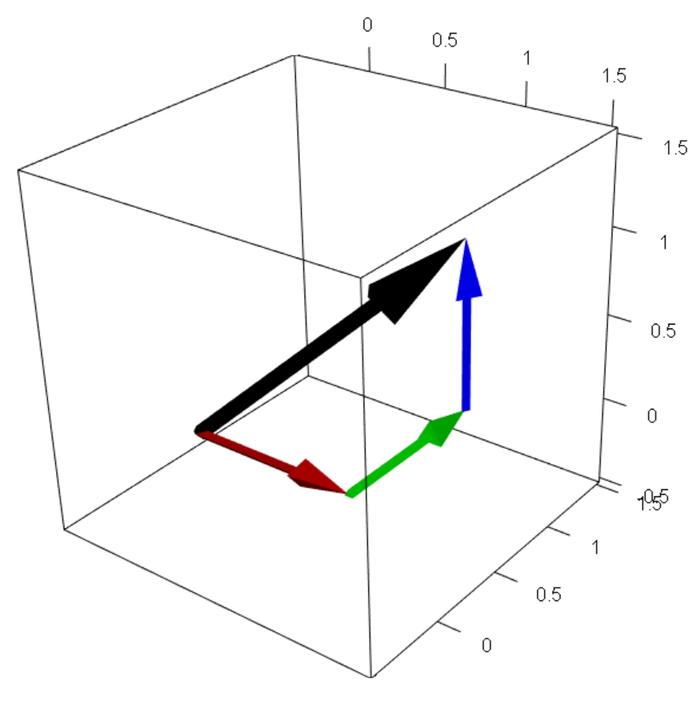

### Column View

Before we looked at $\mathbf{Ax=b}$ with the row view. Meaning, we visualized it with the row equations. Allowing us to see the planes and lines intersect where the solutions are, but we can also look at it with a column view:

$$\begin{bmatrix}
a_{11} & a_{12}\\
a_{21} & a_{22}
\end{bmatrix}
\begin{bmatrix}
x_1\\
x_2
\end{bmatrix} =
\begin{bmatrix}
b_1\\
b_2
\end{bmatrix} \Rightarrow
x_1\begin{bmatrix}
a_{11}\\
a_{21} \end{bmatrix} +
x_2\begin{bmatrix}
a_{12}\\
a_{22}
\end{bmatrix} =
\begin{bmatrix}
x_1a_{11}\\
x_1a_{21} \end{bmatrix} +
\begin{bmatrix}
x_2a_{12}\\
x_2a_{22}
\end{bmatrix} =
\begin{bmatrix}
b_1\\
b_2
\end{bmatrix}$$

This changes our visualization a bit. Now we look at the columns as vectors, and see if there is some way to add them to get our solution. Another way to say this: is there a linear combination of the columns that give us $\mathbf{b}$? Lets look at an example from a previous lecture:

$$\left[ \begin{array}{cc|c}
2 & -1 & 1\\
-1 & 2 & 4
\end{array} \right] \sim
\left[ \begin{array}{cc|c}
1 & 0 & 2\\
0 & 1 & 3
\end{array} \right]$$

We can visualize $\mathbf{A}$ with its columns and $\mathbf{b}$:

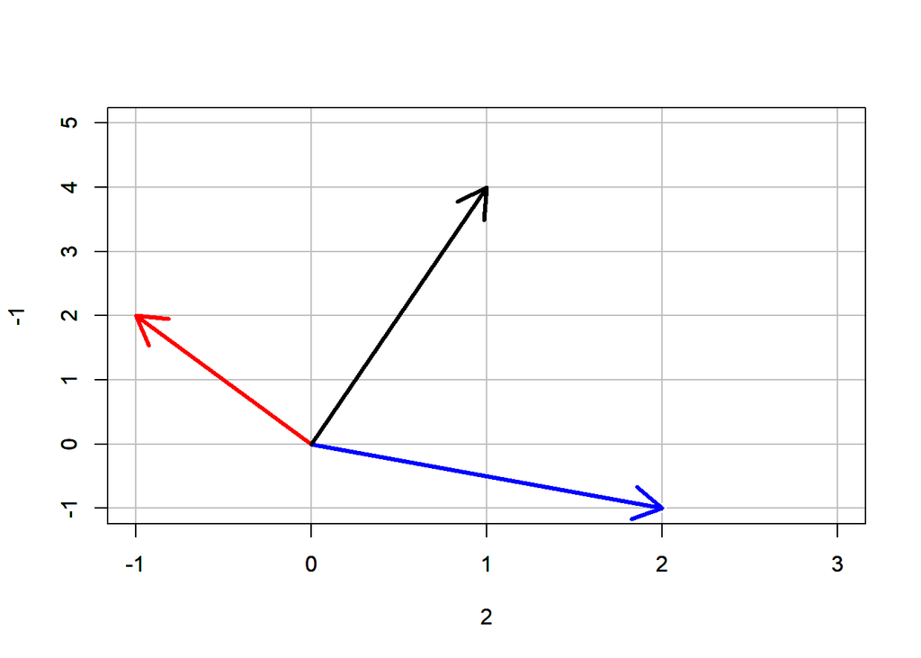

```r
plot(2, -1, col="white", xlim=c(-1, 3), ylim=c(-1, 5))

# Vertical grid
axis(1, tck = 1, lty = 1, col = "gray")

# Horizontal grid
axis(2, tck = 1, lty = 1, col = "gray")

par(new=TRUE)

plot(2, -1, col="white", xlim=c(-1, 3), ylim=c(-1, 5))
arrows(0, 0, 2, -1, col="blue", lwd=3)
arrows(0, 0, -1, 2, col="red", lwd=3)
arrows(0, 0, 1, 4, col="black", lwd=3)

box()
```

Now, with this linear system, we are asking if we can add the red and blue vectors to get the black vector. From the row reduced form, we can see there is exactly one way to do this:

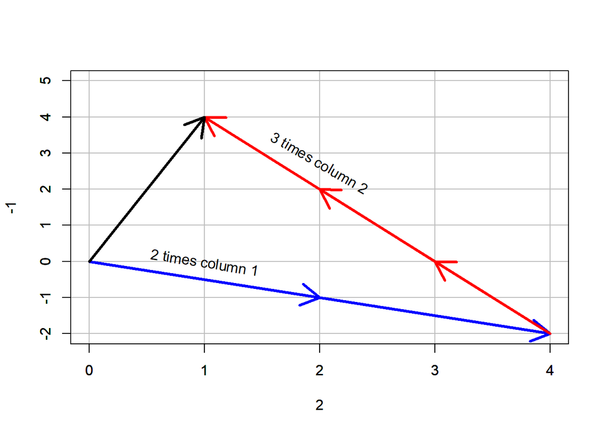

```r
plot(2, -1, col="white", xlim=c(0, 4), ylim=c(-2, 5))

# Vertical grid
axis(1, tck = 1, lty = 1, col = "gray")

# Horizontal grid
axis(2, tck = 1, lty = 1, col = "gray")

par(new=TRUE)

plot(2, -1, col="white", xlim=c(0, 4), ylim=c(-2, 5))
arrows(0, 0, 2, -1, col="blue", lwd=3)
arrows(0, 0, 4, -2, col="blue", lwd=3)
text(x=1, y=0, label="2 times column 1", srt=-9)
arrows(4, -2, 3, 0, col="red", lwd=3)
arrows(3, 0, 2, 2, col="red", lwd=3)
arrows(4, -2, 1, 4, col="red", lwd=3)
text(x=2, y=2.75, label="3 times column 2", srt=-30)
arrows(0, 0, 1, 4, col="black", lwd=3)

box()
```

### Parametric Vector Form

We can write our solutions to our equations in parametric form, so that we have a clean solution. Lets talk another example we’ve used previously:

$$\left[ \begin{array}{ccc|c}
1 & 3 & 1 & 1\\
-4 & -9 & 2 & -1\\
0 & -3 & -6 & -3
\end{array} \right] \sim \left[ \begin{array}{ccc|c}
1 & 0 & -5 & -2\\
0 & 1 & 2 & 1\\
0 & 0 & 0 & 0
\end{array} \right] \Rightarrow \mathbf{x} =
\begin{bmatrix}
5x_3-2 \\
-2x_3+1 \\
x_3
\end{bmatrix} =x_3
\begin{bmatrix}
5 \\
-2 \\
1
\end{bmatrix} +
\begin{bmatrix}
-2\\
1 \\
0
\end{bmatrix} = x_3\mathbf{v} + \mathbf{u}$$

Which means we can write our solution set as $\{x_3\mathbf{v} + \mathbf{u}| x_3 \in \mathbb{C}\}$. Also, we can see the null space easily, $\{x_3\mathbf{v}| x_3 \in \mathbb{C}\}$. For fun, lets visualized the solution to this system with the column view.

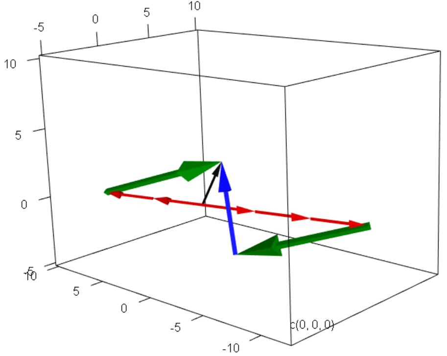

# Linear Combinations

## Definitions and Theorems

### Definition 3.1.

**Linear Combination**

A linear combination of a set of vectors $\{\mathbf{v}_1, \mathbf{v}_2, \dots, \mathbf{v}_m\}, \mathbf{v}_i \in \mathbb{C}^n \ \forall \ i$ is a vector that is formed by multiplying the vectors in the set by scalars and adding them up. We can write a linear combination using sigma notation:

$$\mathbf{u} = \sum^n_{i=1} c_i\mathbf{v}_i,\ c_i \in \mathbb{C}$$

We would say that $\mathbf{u}$ is a linear combination of the vectors in the set $\{\mathbf{v}_1, \mathbf{v}_2, \dots, \mathbf{v}_m\}$.

### Definition 3.2.

**Span**

The span of a set of vectors is the set of all linear combinations of the vectors in the set.

We can write the span of a set in set notation as follows. If $\{\mathbf{v}_1, \mathbf{v}_2, \dots, \mathbf{v}_m\}, \mathbf{v}_i \in \mathbb{C}^n$, then

$$\text{The span of} \ S = \langle S\rangle = \{\mathbf{u} \in \mathbb{C}^n| \mathbf{u} = \sum^n_{i=1} c_i\mathbf{v}_i,\ c_i \in \mathbb{C}\}$$

If $W$ is a set and $\langle S\rangle = W$, then we say $S$ **spans** $W$.

### Theorem 3.1.

**Spanning Sets**

Let $\mathbf{A}$ be an $m \times n$ matrix, let $S$ be the set containing the column vectors of $\mathbf{A}$, and let $\mathbf{B}$ be the reduced row-echelon form of $\mathbf{A}$. The following statements are either all true or all false:

1. The system $\mathcal{LS}(\mathbf{A, b})$ is consistent for all $\mathbf{b}$ in $\mathbb{C}^m$.
2. Every $\mathbf{b}$ in $\mathbb{C}^m$ can be written as a linear combination of the vectors in $S$.
3. $\langle S\rangle = \mathbb{C}^m$.
4. $\mathbf{B}$ has a pivot in every row.

*Proof* I will show that $4 \Rightarrow 1,\ 2,\ \text{and}\ 3$, but the full proof would show that each of the four imply the others.

Let $\mathcal{LS}(\mathbf{A}_{m \times n}, \mathbf{b}_{m \times 1})$ and $\mathbf{A}_{m \times n} \sim \mathbf{B}_{m \times n}$. Assume $\mathbf{B}$ has a pivot in every row.

This means there are some row operations we can reduce $\mathbf{A}$ to $\mathbf{B}$. Which means $[\mathbf{A}|\mathbf{b}]$, has a $m$ pivots columns, none of which are the $\mathbf{b}$ column. By definition, this system is then consistent. Also, whatever $\mathbf{b}$ is doesn’t change the row operations, meaning the system is true $\forall \mathbf{b} \in \mathbb{C}^m$. ($4 \Rightarrow 1$)

Since the system is consistent, this means that $\mathbf{b}$ is a linear combination of the columns in $\mathbf{A}$. The columns in $\mathbf{A}$ are the elements of $S$ by assumption, meaning $\forall \mathbf{b} \in \mathbb{C}^m$ can be written as a linear combination of the vectors in $S$. ($4 \Rightarrow 2$)

Since $\forall \mathbf{b} \in \mathbb{C}^m$ a linear combination of the vectors in $S$ is equivalent. This means the $\langle S\rangle = \mathbb{C}^m$ by definition of span. ($4 \Rightarrow 3$)

## Examples

Let

$$S = \Bigg\{ \begin{bmatrix}
3\\
0\\
-6
\end{bmatrix},
\begin{bmatrix}
3\\
1\\
-5
\end{bmatrix},
\begin{bmatrix}
2\\
2\\
8
\end{bmatrix}\Bigg\} = \{\mathbf{v}_1,\mathbf{v}_2,\mathbf{v}_3\}$$

List a few different vectors in $\langle S\rangle$ on your own, and think about what the (entire) span of S is. How many vectors are in $\langle S\rangle$?

**Click here Solution**

Any linear combination of the vectors in $S$ would work. We can write the entire span as $\langle S\rangle = \{c_1\mathbf{v}_1+c_2\mathbf{v}_2+c_3\mathbf{v}_3| c_1,c_2,c_3 \in \mathbb{C}\}$. We can easily see there are infinitely many elements in this set, as there are infinitely many $c_i$’s to choose from.

Now let $S = \{\mathbf{u}, \mathbf{v}, \mathbf{w}\}$. Find $\langle S\rangle$.

**Click here Solution**

Since we are not given specific vectors, $\langle S\rangle = \{c_1\mathbf{u}+c_2\mathbf{v}+c_3\mathbf{w}| c_1,c_2,c_3 \in \mathbb{C}\}$

Again let,

$$S = \Bigg\{ \begin{bmatrix}
3\\
0\\
-6
\end{bmatrix},
\begin{bmatrix}
3\\
1\\
-5
\end{bmatrix},
\begin{bmatrix}
2\\
2\\
8
\end{bmatrix}\Bigg\} = \{\mathbf{v}_1,\mathbf{v}_2,\mathbf{v}_3\}$$

is $\begin{bmatrix} 5\\ 1\\ 8 \end{bmatrix}$ in $\langle S\rangle$? Further, does $S$ span $\mathbb{C}^3$?

**Click here Solution**

$\begin{bmatrix} 5\\ 1\\ 8 \end{bmatrix} \in \langle S\rangle$ if $\begin{bmatrix} 5\\ 1\\ 8 \end{bmatrix}$ is a linear combination of the elements of $S$. We have done this exact problem is previous lectures, $\mathbf{Ax=b}$. How do we know if $\begin{bmatrix} 5\\ 1\\ 8 \end{bmatrix}$ is a linear combination? Well, if $\mathbf{Ax=b}$ is consistent, then we know there is at least one solution.

$$\left[ \begin{array}{ccc|c}
3 & 3 & 2 & 5\\
0 & 1 & 2 & 1\\
-6 & -5 & 8 & 8
\end{array} \right] \sim \left[ \begin{array}{ccc|c}
1 & 0 & 0 & \frac{44}{15}\\
0 & 1 & 0 & -\frac{12}{5}\\
0 & 0 & 1 & \frac{17}{10}
\end{array} \right]$$

Thus the system is consistent and the solution unique. Particularly, we have the following linear combination:

$$\begin{bmatrix} 5\\ 1\\ 8 \end{bmatrix} = \frac{44}{15}\begin{bmatrix}
3\\
0\\
-6
\end{bmatrix} +
-\frac{12}{5}\begin{bmatrix}
3\\
1\\
-5
\end{bmatrix} +
\frac{17}{10}\begin{bmatrix}
2\\
2\\
8
\end{bmatrix}$$

Lastly, let

$$\mathbf{A} = \begin{bmatrix}
3 & 3 & 2\\
0 & 1 & 1\\
-6 & -5 & -3
\end{bmatrix}$$

Is $\mathcal{C}(\mathbf{A}) = \mathbb{C}^3$? Why or why not? ($\mathcal{C}(\mathbf{A})$ is the span of the columns of $\mathbf{A}$, also known as the column space)

**Click here Solution**

when we row reduce $\mathbf{A}$, we get:

$$\begin{bmatrix}
1 & 0 & -\frac{1}{3}\\
0 & 1 & 1\\
0 & 0 & 0
\end{bmatrix}$$